# Predicting Probability of Defaulters

Group 3

## Objective

This model was been built to determine probability of customers to be defaulters/non-defaulters

## Libraries

Loading required libraries into work-space

```r
library(dplyr)
library(caret)
library(readr)
library(broom)
library(pROC)
library(randomForest)
library(gmodels)
library(ROCR)
```

## Data Cleaning

Importing training data, converting loss column to factor containing 1 and 0; 1 means defaulters , 0 means non-defaulter. Finally, eliminating extra ID columns.

```r
raw_data <- read_csv("train_v3(1).csv")

raw_data$X1 <- NULL

raw_data$type <- as.factor(ifelse(raw_data$loss ==0,0,1))

raw_data$loss <- NULL
```

First, we eliminate all *duplicate* columns

```r
data_uni <-raw_data[!duplicated(as.list(raw_data))]
```

Before *standardizing* the data we check *zero variance* across all column.

```r
dummy <- nearZeroVar(data_uni)

data_nzv <- data_uni[,-dummy]

anyNA(data_nzv)
```

```
## [1] TRUE
```

Before we go further we need to check for missing values in our data. This can be done using imputation techniques; here we are replacing missing values with **median imputation technique**

```r
data_nzv <- data.frame(data_nzv)

impute<- preProcess(data_nzv,method = "medianImpute")

data_imt <- predict(impute,data_nzv)

anyNA(data_imt)
```

```
## [1] FALSE
```

## Preprocessing

We must now partition data into train and test splits.

```r
set.seed(123)

data.index <- createDataPartition( data_imt$f3, p=0.75, list = FALSE)

train_l <- data_imt[ data.index, ]

test_l <- data_imt[ -data.index, ]
```

## Model Construction

### Logistic Regression

The goal here is to predict if a customer is defaulter/non-defaulter. Since this is a binary class classification, *logistic regression* is the best-suited techinque.

```r
logit_model <- glm(type ~., data = train_l, family = binomial)
```

**Cross Validation:**

```r
levels(train_l$type)
```

```
## [1] "0" "1"
```

```r
# predicting probablity for traget varilable of class "1" who are defaulters

logit_pred_test <- predict(logit_model, test_l, type="response")

# converting probabilities into class of either "0" or "1"

prediction_test <- as.factor(ifelse(logit_pred_test > 0.5,1,0))

# checking performance metric for test data

(perf_metric<- confusionMatrix(prediction_test,test_l$type))
```

```
## Confusion Matrix and Statistics
##
##           Reference
## Prediction     0     1
##          0 18166  1739
##          1    45    50
##
##                Accuracy : 0.9108
##                  95% CI : (0.9068, 0.9147)
##     No Information Rate : 0.9106
##     P-Value [Acc > NIR] : 0.4569
##
##                   Kappa : 0.0445
##
##  Mcnemar's Test P-Value : <2e-16
##
##             Sensitivity : 0.99753
##             Specificity : 0.02795
##          Pos Pred Value : 0.91264
##          Neg Pred Value : 0.52632
##              Prevalence : 0.91055
##          Detection Rate : 0.90830
##    Detection Prevalence : 0.99525
##       Balanced Accuracy : 0.51274
##
##        'Positive' Class : 0
##
```

From the performance matrix we see **accuracy** of **0.9108** for test data. If we see **No Information Rate** is at **0.9106** this implies largest proportion of the observed classes here are non-defaulters. A hypothesis test is also computed to evaluate whether the overall accuracy rate is greater than the rate of the largest class.

```
##
##     0     1
## 72621  7379
```

Above table depicts classes of data : non-default (0) and default (1).

```
##    prediction_test
##         0     1
##   0 18166    45
##   1  1739    50
```

We found predictions from the model are biased towards non-default class as they are more prevalent across the dataset. This can also be seen in the difference between **Sensitivity** as **0.997529** and **Specficity** as **0.0279486**. Hence, there is need to evenly *balance* the data.

### Balancing data

```r
set.seed(123)

# As defaulters class is less, we will be sampling same no of non-defaulters
index <- sample(length(data_imt$type[data_imt$type==0]),length(data_imt$type[data_imt$type==1]))

# filter non-defaulters data
data_imt_0 <- data_imt %>% filter( type == 0)

# filter defaulters data
data_imt_1 <- data_imt %>%  filter(type == 1)

# Creating balanced dataset
data_imt_0 <- data_imt_0[index,]

data_imt <-  as.data.frame( rbind( data_imt_0, data_imt_1))

table(data_imt$type)
```

```
##
##    0    1
## 7379 7379
```

### Constructing logistic regression for balanced data

```r
set.seed(123)

data.index <- createDataPartition(data_imt$f3,p=0.75,list = FALSE)

train <- data_imt[data.index,]

test <- data_imt[-data.index,]
```

```r
# Logistic Regression Model

logit_model_balanced <- glm(type~., data=train[,-1],family = "binomial")

# Predicting the probabilities of defaulters.

logit_pred_test_balanced <- predict(logit_model_balanced,test[,-1],type="response")

# converting probabilities into class of either "0" or "1"

pred1 <- as.factor(ifelse(logit_pred_test_balanced > 0.5,1,0))
```

**Cross Validation** of predicted data vs actual data

```r
CrossTable(x=test$type, y=pred1, prop.chisq = FALSE)
```

```
##
##
##    Cell Contents
## |-------------------------|
## |                       N |
## |           N / Row Total |
## |           N / Col Total |
## |         N / Table Total |
## |-------------------------|
##
##
## Total Observations in Table:  3688
##
##
##              | pred1
##    test$type |         0 |         1 | Row Total |
## -------------|-----------|-----------|-----------|
##            0 |      1170 |       676 |      1846 |
##              |     0.634 |     0.366 |     0.501 |
##              |     0.660 |     0.353 |           |
##              |     0.317 |     0.183 |           |
## -------------|-----------|-----------|-----------|
##            1 |       602 |      1240 |      1842 |
##              |     0.327 |     0.673 |     0.499 |
##              |     0.340 |     0.647 |           |
##              |     0.163 |     0.336 |           |
## -------------|-----------|-----------|-----------|
## Column Total |      1772 |      1916 |      3688 |
##              |     0.480 |     0.520 |           |
## -------------|-----------|-----------|-----------|
##
##
```

**Performance Metrics** of test data

```r
confusionMatrix(test$type, pred1)
```

```
## Confusion Matrix and Statistics
##
##           Reference
## Prediction    0    1
##          0 1170  676
##          1  602 1240
##
##                Accuracy : 0.6535
##                  95% CI : (0.6379, 0.6688)
##     No Information Rate : 0.5195
##     P-Value [Acc > NIR] : < 2e-16
##
##                   Kappa : 0.307
##
##  Mcnemar's Test P-Value : 0.04115
##
##             Sensitivity : 0.6603
##             Specificity : 0.6472
##          Pos Pred Value : 0.6338
##          Neg Pred Value : 0.6732
##              Prevalence : 0.4805
##          Detection Rate : 0.3172
##    Detection Prevalence : 0.5005
##       Balanced Accuracy : 0.6537
##
##        'Positive' Class : 0
##
```

**ROC**

```r
ROC <- roc(test$type,logit_pred_test_balanced)
```

AUC value of the model is **0.7133427**

### Regularized Regression Model

Logistic regression using lasso (L1) regularization. We have 658 variables in training set, Lasso regresssion has the capability to zero out the coefficients of non-significant variables and consider only significant variables to train the model with.

```r
set.seed(123)

myControl <- trainControl(method = "cv",
                          number = 5,
                          summaryFunction = twoClassSummary,
                          classProbs = TRUE
                          ,verboseIter = TRUE)

model_ct <- train(make.names(type)~.,data=train,method="glmnet",trControl=myControl)
```

### Prediction on Test data

```r
pred_cv <- predict(model_ct,test)

# Cross Validation on Test data

CrossTable(x=test$type,y=pred_cv, prop.chisq = FALSE)
```

```
##
##
##    Cell Contents
## |-------------------------|
## |                       N |
## |           N / Row Total |
## |           N / Col Total |
## |         N / Table Total |
## |-------------------------|
##
##
## Total Observations in Table:  3688
##
##
##              | pred_cv
##    test$type |        X0 |        X1 | Row Total |
## -------------|-----------|-----------|-----------|
##            0 |      1179 |       667 |      1846 |
##              |     0.639 |     0.361 |     0.501 |
##              |     0.665 |     0.348 |           |
##              |     0.320 |     0.181 |           |
## -------------|-----------|-----------|-----------|
##            1 |       595 |      1247 |      1842 |
##              |     0.323 |     0.677 |     0.499 |
##              |     0.335 |     0.652 |           |
##              |     0.161 |     0.338 |           |
## -------------|-----------|-----------|-----------|
## Column Total |      1774 |      1914 |      3688 |
##              |     0.481 |     0.519 |           |
## -------------|-----------|-----------|-----------|
##
##
```

```r
# Perforamnce metrics of Test data

test1 <- test$type

levels(test1) <- c("X0","X1")

confusionMatrix(test1,pred_cv)
```

```
## Confusion Matrix and Statistics
##
##           Reference
## Prediction   X0   X1
##         X0 1179  667
##         X1  595 1247
##
##                Accuracy : 0.6578
##                  95% CI : (0.6422, 0.6731)
##     No Information Rate : 0.519
##     P-Value [Acc > NIR] : < 2e-16
##
##                   Kappa : 0.3156
##
##  Mcnemar's Test P-Value : 0.04565
##
##             Sensitivity : 0.6646
##             Specificity : 0.6515
##          Pos Pred Value : 0.6387
##          Neg Pred Value : 0.6770
##              Prevalence : 0.4810
##          Detection Rate : 0.3197
##    Detection Prevalence : 0.5005
##       Balanced Accuracy : 0.6581
##
##        'Positive' Class : X0
##
```

**ROC**

```r
pred_roc <- predict(model_ct,test,type = "prob")

ROC_cv <- roc(test$type,pred_roc[,2])
```

AUC for lasso model is **0.7193127**

## Ensemble Method

### Random Forest Model

Constructing the Random Forest model to predict the target variable

```r
set.seed(123)

rf.model <- randomForest(type~.,
                         data=train[,-1],
                         ntree = 700,
                         mtry=c(25,50,100),
                         importance=TRUE)

# Predicitng the target varialbe

pred_rf <- predict(rf.model,test)
```

**Cross Validation**

```r
CrossTable(x=test$type,y=pred_rf, prop.chisq = FALSE)
```

```
##
##
##    Cell Contents
## |-------------------------|
## |                       N |
## |           N / Row Total |
## |           N / Col Total |
## |         N / Table Total |
## |-------------------------|
##
##
## Total Observations in Table:  3688
##
##
##              | pred_rf
##    test$type |         0 |         1 | Row Total |
## -------------|-----------|-----------|-----------|
##            0 |      1097 |       749 |      1846 |
##              |     0.594 |     0.406 |     0.501 |
##              |     0.646 |     0.376 |           |
##              |     0.297 |     0.203 |           |
## -------------|-----------|-----------|-----------|
##            1 |       600 |      1242 |      1842 |
##              |     0.326 |     0.674 |     0.499 |
##              |     0.354 |     0.624 |           |
##              |     0.163 |     0.337 |           |
## -------------|-----------|-----------|-----------|
## Column Total |      1697 |      1991 |      3688 |
##              |     0.460 |     0.540 |           |
## -------------|-----------|-----------|-----------|
##
##
```

**Performance Metrics**

```r
confusionMatrix(test$type,pred_rf)
```

```
## Confusion Matrix and Statistics
##
##           Reference
## Prediction    0    1
##          0 1097  749
##          1  600 1242
##
##                Accuracy : 0.6342
##                  95% CI : (0.6184, 0.6498)
##     No Information Rate : 0.5399
##     P-Value [Acc > NIR] : < 2.2e-16
##
##                   Kappa : 0.2685
##
##  Mcnemar's Test P-Value : 5.589e-05
##
##             Sensitivity : 0.6464
##             Specificity : 0.6238
##          Pos Pred Value : 0.5943
##          Neg Pred Value : 0.6743
##              Prevalence : 0.4601
##          Detection Rate : 0.2975
##    Detection Prevalence : 0.5005
##       Balanced Accuracy : 0.6351
##
##        'Positive' Class : 0
##
```

**ROC Curves**

```r
pred_rf_roc <- predict(rf.model,test,type="prob")

ROC_rf <- roc(test$type,pred_rf_roc[,2])
```

AUC value for random forest model is **0.6827454**

The below plot depicts the most relevant variables chosen by the Random Forest algorithm

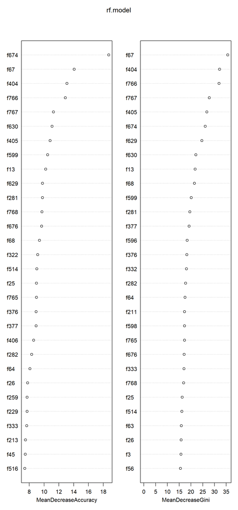

```r
varImpPlot(rf.model)
```

When the number of variables is large, but the fraction of **relevant variables is small**, random forests are likely to perform poorly when **m** (no. of revelant variables) is small. Why? Because, at each split the chance is small that the relevant variables will be selected. For example, with 3 relevant and 100 minimally relevant variables, the probability of any of the relevant variables being selected at any split is ~ 0.25

## Conclusion

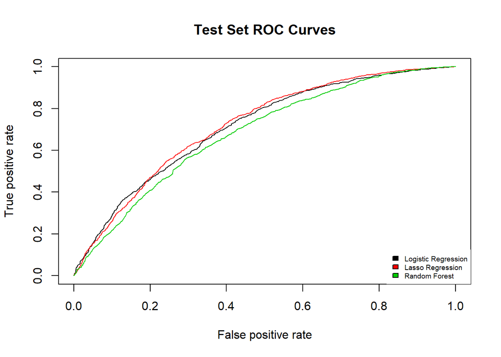

Based on above plot we see lasso model is performing better than logistic or random forest model. Thus, we will be using lasso model to predict target variable for test scenario.

Saving Lasso regression model for future use.

```r
lasso_pd <- model_ct
saveRDS(lasso_pd, "./lasso_pd.rds")
```